# Peer-graded Assignment: Machine learning Course Project

## Executive summary

The goal of your project is to predict the manner in which the participants did the exercise.

## 1. Question

In which manner they did the participants the exercise?

## 2. Input data

Weight Lifting Exercises Dataset. Six young health participants were asked to perform one set of 10 repetitions of the Unilateral Dumbbell Biceps Curl in five different fashions: exactly according to the specification (Class A), throwing the elbows to the front (Class B), lifting the dumbbell only halfway (Class C), lowering the dumbbell only halfway (Class D) and throwing the hips to the front (Class E). The data for this project was generously offered by: http://groupware.les.inf.puc-rio.br/har.

### Load data & tidy up

(Larger K=less bias, more variance; smaller k= more bias, less variance–> 20=accurate )

```r
library(plyr)
library(dplyr)
library(ggplot2)
library(grid)
library(gridExtra)
library(caret)
library(rpart)
library(randomForest)

testing<-read.csv("pml-testing.csv")
training<-read.csv("pml-training.csv")
testing$classe
#-->Note: "classe" is not a variable of the testing dataset

training <- training[, colSums(is.na(training)) == 0]


# delete unnecessary data (timestamp etc)
training[3,1:10]
training <- training[, -c(1:7)]
```

### Cross validation as there is no variable “classe” in the testing data set. Split: training data 60%, testing data 40%

```r
#transform factors in numeric vectors
for(i in 1:85){
if (class(training[,i])=="factor")
    {training[,i]<-as.numeric(training[,i])}}

inTrain<-createDataPartition(y=training$classe,p=0.60,list=FALSE)
training_set<-training[inTrain,]
testing_set<-training[-inTrain,]
```

## 3. Algorithm

### Classification tree

```r
ModFitDecTree <- rpart(classe ~ ., data=training_set, method="class")
pred_decTree<-predict(ModFitDecTree,newdata = testing_set,type="class")
confusionMatrix(pred_decTree,testing_set$classe)
```

```
## Confusion Matrix and Statistics
##
##           Reference
## Prediction    A    B    C    D    E
##          A 2082  242   26   78   14
##          B   63  844   69   94  110
##          C   38  297 1172  137  192
##          D   38   98   99  873  101
##          E   11   37    2  104 1025
##
## Overall Statistics
##
##                Accuracy : 0.7642
##                  95% CI : (0.7547, 0.7736)
##     No Information Rate : 0.2845
##     P-Value [Acc > NIR] : < 2.2e-16
##
##                   Kappa : 0.701
##  Mcnemar's Test P-Value : < 2.2e-16
##
## Statistics by Class:
##
##                      Class: A Class: B Class: C Class: D Class: E
## Sensitivity            0.9328   0.5560   0.8567   0.6788   0.7108
## Specificity            0.9359   0.9469   0.8975   0.9488   0.9760
## Pos Pred Value         0.8526   0.7153   0.6383   0.7221   0.8694
## Neg Pred Value         0.9722   0.8989   0.9674   0.9378   0.9375
## Prevalence             0.2845   0.1935   0.1744   0.1639   0.1838
## Detection Rate         0.2654   0.1076   0.1494   0.1113   0.1306
## Detection Prevalence   0.3112   0.1504   0.2340   0.1541   0.1503
## Balanced Accuracy      0.9343   0.7514   0.8771   0.8138   0.8434
```

### Random Forest

```r
set.seed(3141600)
ModelFit_rf <- randomForest(classe~., data=training_set, importance=TRUE, ntree=100)

pred_rf<-predict(ModelFit_rf,newdata = testing_set)
confusionMatrix(pred_rf,testing_set$classe)
```

```
## Confusion Matrix and Statistics
##
##           Reference
## Prediction    A    B    C    D    E
##          A 2227   13    0    0    0
##          B    4 1498   15    0    0
##          C    1    7 1352   22    0
##          D    0    0    1 1262    7
##          E    0    0    0    2 1435
##
## Overall Statistics
##
##                Accuracy : 0.9908
##                  95% CI : (0.9885, 0.9928)
##     No Information Rate : 0.2845
##     P-Value [Acc > NIR] : < 2.2e-16
##
##                   Kappa : 0.9884
##  Mcnemar's Test P-Value : NA
##
## Statistics by Class:
##
##                      Class: A Class: B Class: C Class: D Class: E
## Sensitivity            0.9978   0.9868   0.9883   0.9813   0.9951
## Specificity            0.9977   0.9970   0.9954   0.9988   0.9997
## Pos Pred Value         0.9942   0.9875   0.9783   0.9937   0.9986
## Neg Pred Value         0.9991   0.9968   0.9975   0.9964   0.9989
## Prevalence             0.2845   0.1935   0.1744   0.1639   0.1838
## Detection Rate         0.2838   0.1909   0.1723   0.1608   0.1829
## Detection Prevalence   0.2855   0.1933   0.1761   0.1619   0.1832
## Balanced Accuracy      0.9977   0.9919   0.9918   0.9901   0.9974
```

As there are some variables in the testing data , which just just “NAs”, we will use not all variables to answer the QUIZ. To find the most important variables, we are using varImpPlot.

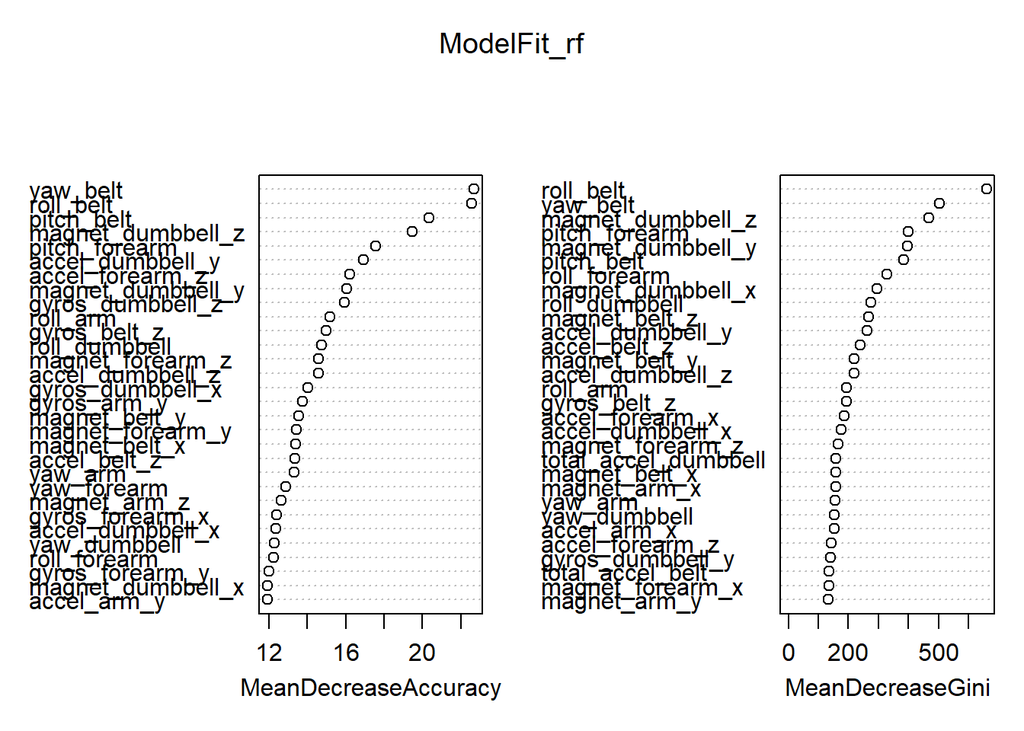

```r
varImpPlot(ModelFit_rf)
```

```r
set.seed(3141600)

ModelFit_rf2 <- randomForest(classe~yaw_belt+roll_belt+magnet_dumbbell_z+pitch_belt+pitch_forearm+gyros_arm_y, data=training_set, importance=TRUE, ntree=100)

pred_rf2<-predict(ModelFit_rf2,newdata = testing_set)
confusionMatrix(pred_rf2,testing_set$classe)
```

```
## Confusion Matrix and Statistics
##
##           Reference
## Prediction    A    B    C    D    E
##          A 2198   24    9    0    2
##          B   17 1451   11    3   12
##          C   10   37 1332   10    5
##          D    6    3   16 1273    6
##          E    1    3    0    0 1417
##
## Overall Statistics
##
##                Accuracy : 0.9777
##                  95% CI : (0.9742, 0.9808)
##     No Information Rate : 0.2845
##     P-Value [Acc > NIR] : < 2.2e-16
##
##                   Kappa : 0.9718
##  Mcnemar's Test P-Value : 2.118e-05
##
## Statistics by Class:
##
##                      Class: A Class: B Class: C Class: D Class: E
## Sensitivity            0.9848   0.9559   0.9737   0.9899   0.9827
## Specificity            0.9938   0.9932   0.9904   0.9953   0.9994
## Pos Pred Value         0.9843   0.9712   0.9555   0.9762   0.9972
## Neg Pred Value         0.9939   0.9895   0.9944   0.9980   0.9961
## Prevalence             0.2845   0.1935   0.1744   0.1639   0.1838
## Detection Rate         0.2801   0.1849   0.1698   0.1622   0.1806
## Detection Prevalence   0.2846   0.1904   0.1777   0.1662   0.1811
## Balanced Accuracy      0.9893   0.9745   0.9821   0.9926   0.9910
```

## 4. Results

```r
pred<-predict(ModelFit_rf2,newdata = testing)
pred
```

```
##  1  2  3  4  5  6  7  8  9 10 11 12 13 14 15 16 17 18 19 20
##  B  A  B  A  A  E  D  B  A  A  B  C  B  A  E  E  A  B  B  B
## Levels: A B C D E
```

## APPENDIX:

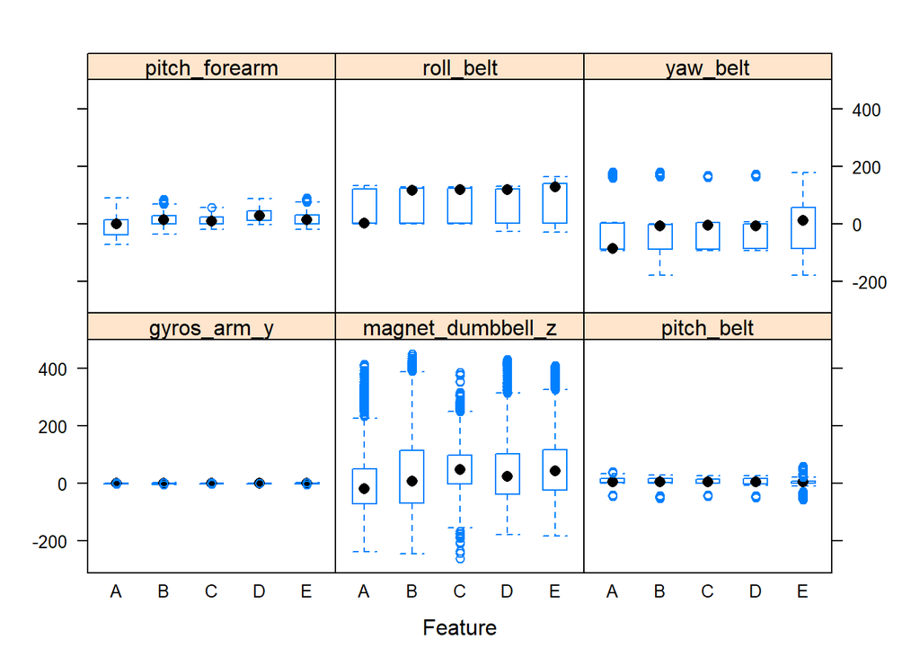

```r
#some additional analysis
featurePlot(x=training_set[,c("yaw_belt","roll_belt","magnet_dumbbell_z","pitch_belt","pitch_forearm","gyros_arm_y")],y=training_set$classe,plot="box")
```

```r
data<-group_by(training_set, classe)
data1<-summarize_each(data,funs(mean(., na.rm = TRUE)))
```

Read more: http://groupware.les.inf.puc-rio.br/har#ixzz4rpKV18aZ